# Distributions

Zechariah Meunier

2025-05-05

Note, all distribution descriptions are modified from their respective Wikipedia pages.

## Discrete Distributions

### Uniform Distribution

The discrete uniform distribution is a symmetric probability distribution wherein each of some finite whole number $n$ of outcome values are equally likely to be observed. Thus, every one of the $n$ outcome values has equal probability $1/n$. Intuitively, a discrete uniform distribution is a known, finite number of outcomes all equally likely to happen.

Although it’s supposed to be symmetric, the symmetry is actually dependent on the sample size. For example, when $n = 10$, it’s not a very flat probability mass function (PMF).

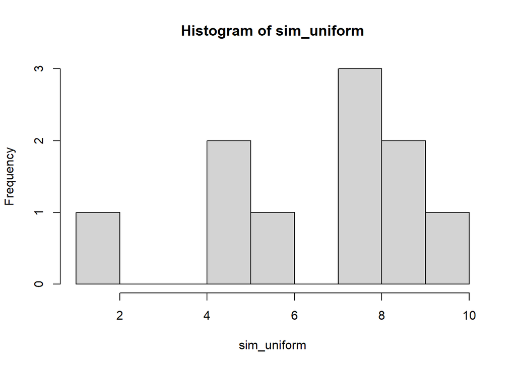

```r
sim_uniform <- runif(n = 10, min = 0, max = 10)
hist(sim_uniform, breaks = round(max(sim_uniform)+1))
```

Increasing `n` to 100 or 1000 improves the symmetry or flatness of the PMF.

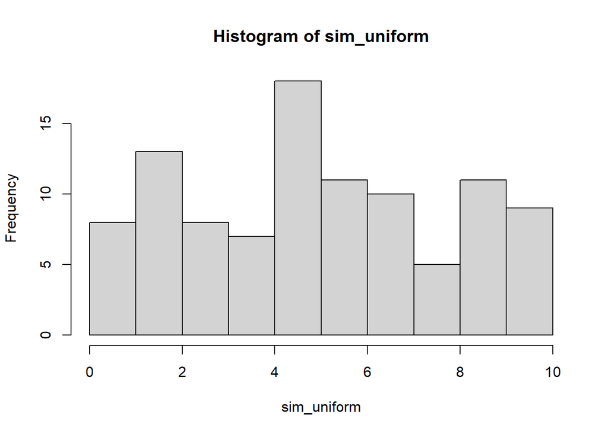

```r
sim_uniform <- runif(n = 100, min = 0, max = 10)
hist(sim_uniform, breaks = round(max(sim_uniform)+1))
```

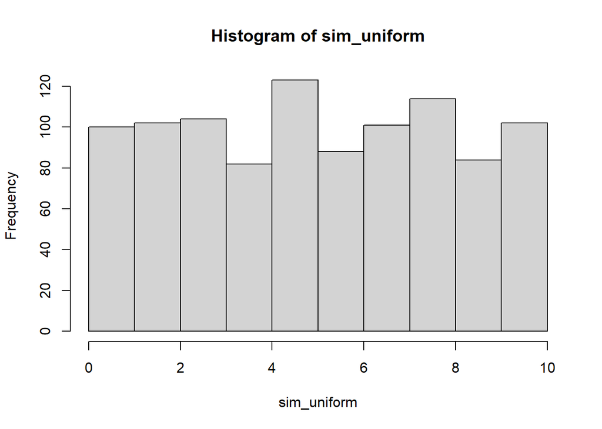

```r
sim_uniform <- runif(n = 1000, min = 0, max = 10)
hist(sim_uniform, breaks = round(max(sim_uniform)+1))
```

### Bernoulli Distribution

The Bernoulli distribution, named after Swiss mathematician Jacob Bernoulli, is the discrete probability distribution of a random variable which takes the value 1 with probability $p$ and the value 0 with probability $q = 1 − p$. Less formally, it can be thought of as a model for the set of possible outcomes of any single experiment that asks a yes–no question. Such questions lead to outcomes that are Boolean-valued: a single bit whose value is success/yes/true/one with probability $p$ and failure/no/false/zero with probability $q$. It can be used to represent a (possibly biased) coin toss where 1 and 0 would represent “heads” and “tails”, respectively, and $p$ would be the probability of the coin landing on heads (or vice versa where 1 would represent tails and $p$ would be the probability of tails). In particular, unfair coins would have $p ≠ 1 / 2$.

The Bernoulli distribution is a special case of the binomial distribution where a single trial is conducted. Somewhat confusingly, the keyword argument `size` is the number of trials, whereas `n` is the number of observations/experiments (so `size` would be 1 for a Bernoulli distribution).

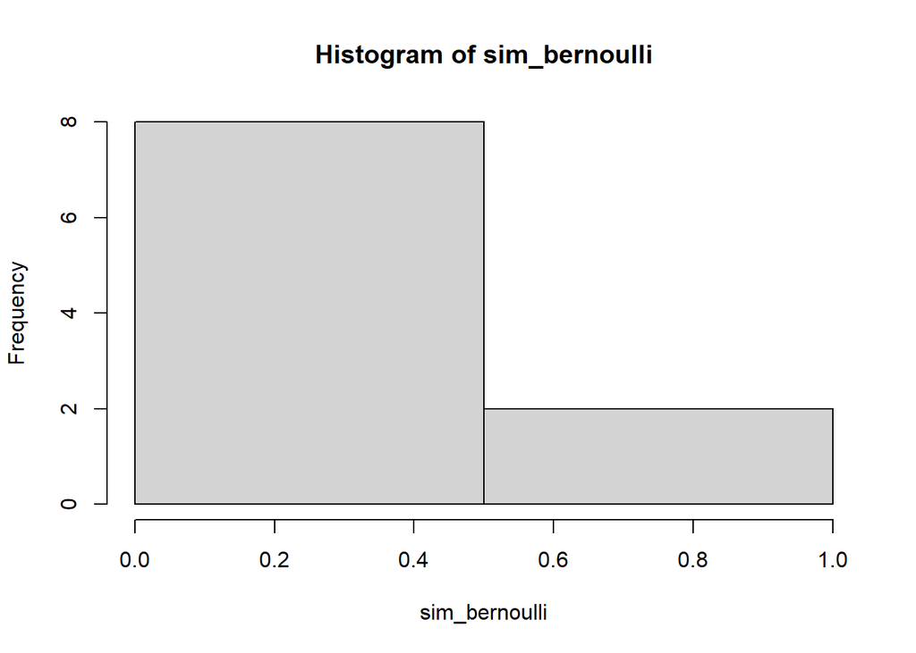

```r
sim_bernoulli <- rbinom(n = 10, size = 1, prob = 0.5)
hist(sim_bernoulli, breaks = round(max(sim_bernoulli)+1))
```

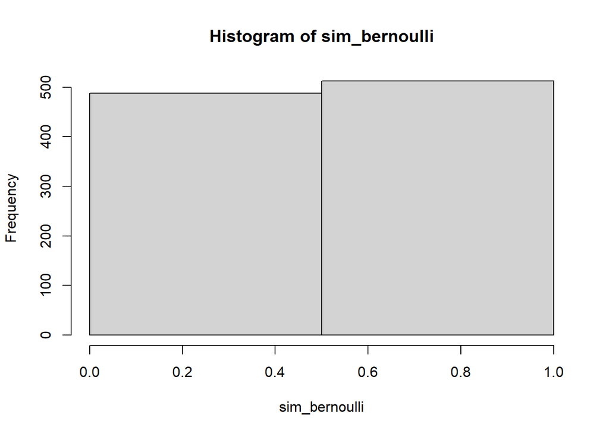

```r
sim_bernoulli <- rbinom(n = 1000, size = 1, prob = 0.5)
hist(sim_bernoulli, breaks = round(max(sim_bernoulli)+1))
```

### Binomial Distribution

The binomial distribution with parameters $n$ and $p$ is the discrete probability distribution of the number of successes in a sequence of $n$ independent experiments, each asking a yes–no question, and each with its own Boolean-valued outcome: success (with probability $p$) or failure (with probability $q = 1 − p$). A single success/failure experiment is also called a Bernoulli trial or Bernoulli experiment, and a sequence of outcomes is called a Bernoulli process. Again, for a single trial, the binomial distribution is a Bernoulli distribution.

We can create a binomial distribution by modifying the above code for the Bernoulli distribution, increasing `size` to 10 so that the experiments consist of 10 trials.

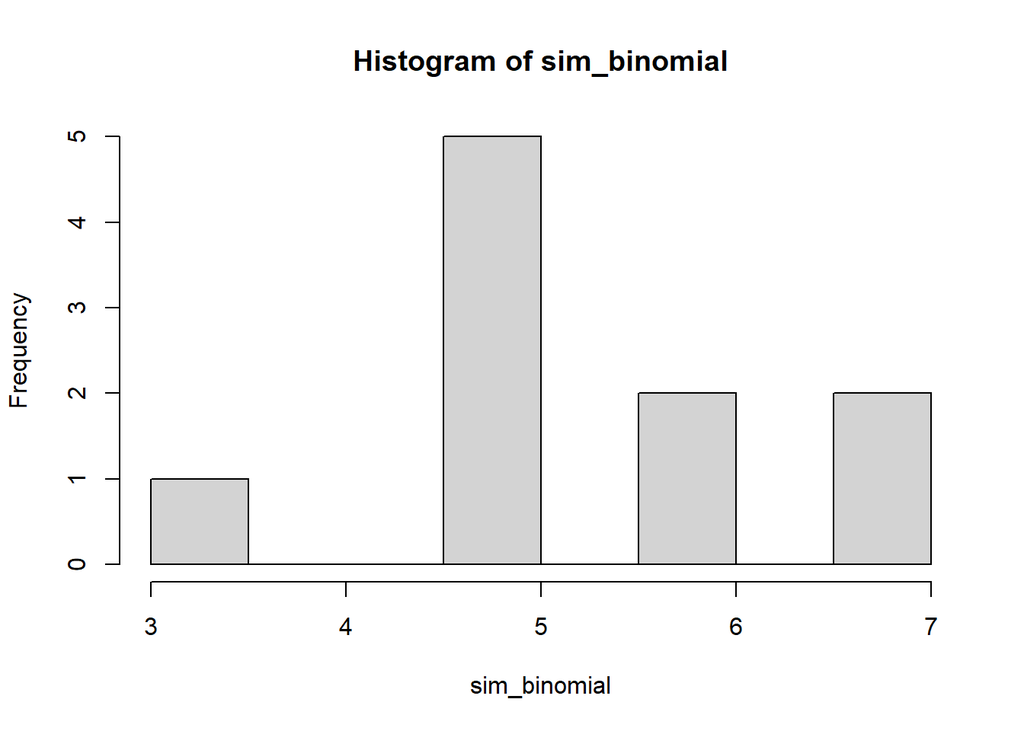

```r
sim_binomial <- rbinom(n = 10, size = 10, prob = 0.5)
hist(sim_binomial, breaks = round(max(sim_binomial)+1))
```

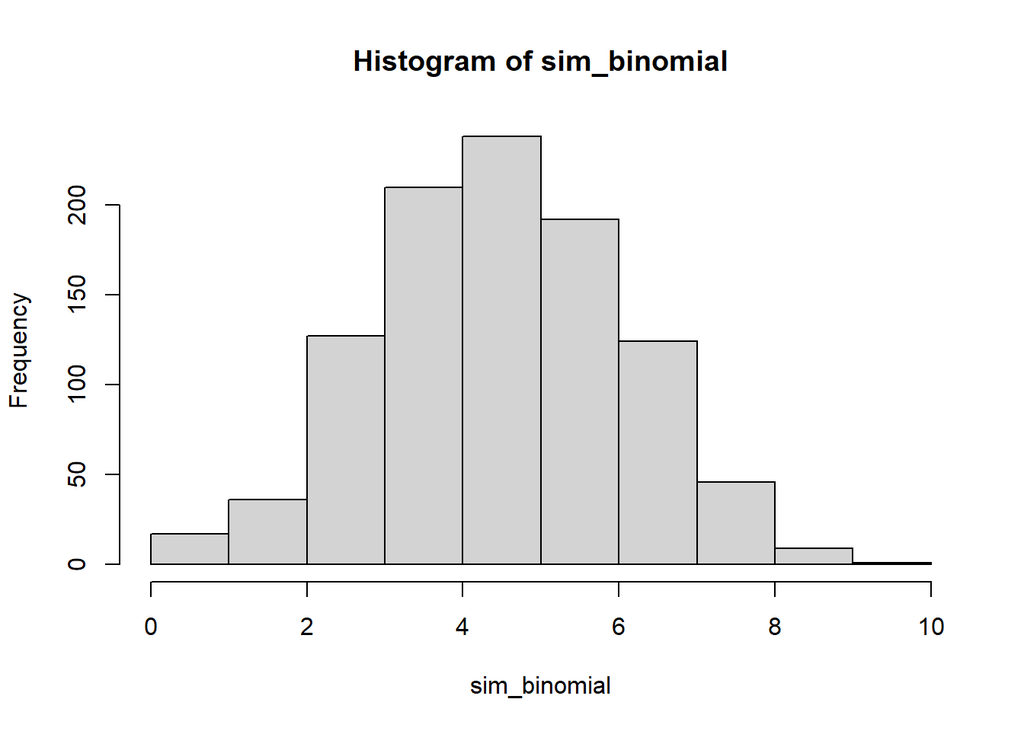

```r
sim_binomial <- rbinom(n = 1000, size = 10, prob = 0.5)
hist(sim_binomial, breaks = round(max(sim_binomial)+1))
```

### Poisson Distribution

The Poisson distribution is a discrete probability distribution that expresses the probability of a given number of events occurring in a fixed interval of time if these events occur with a known constant mean rate and independently of the time since the last event. It can also be used for the number of events in other types of intervals than time, and in dimension greater than 1 (e.g., number of events in a given area or volume). The Poisson distribution is named after French mathematician Siméon Denis Poisson.

The Poisson distribution has a single parameter $\lambda$ or `lambda`, which is the mean and the variance.

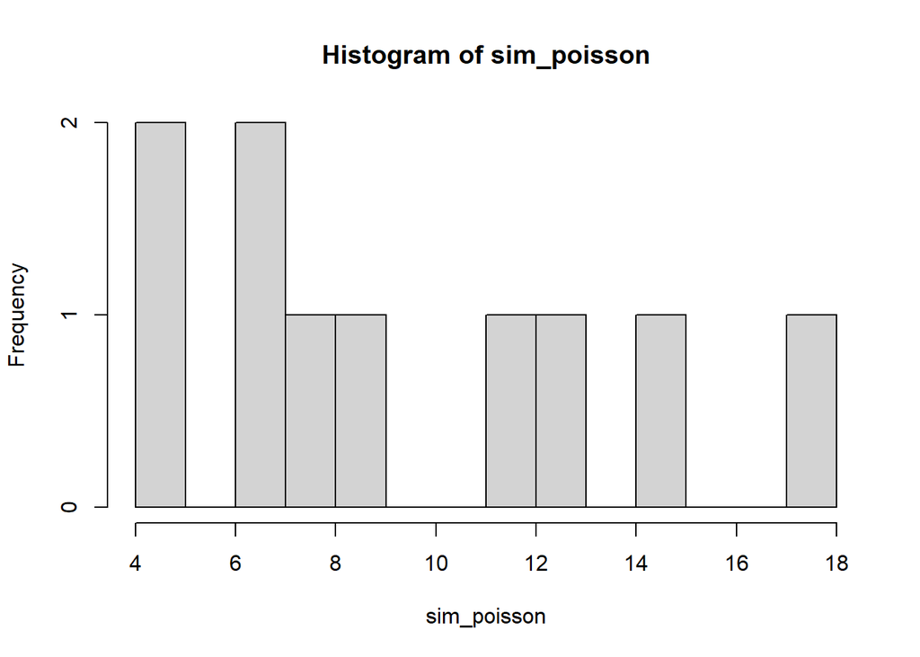

```r
sim_poisson <- rpois(n = 10, lambda = 10)
hist(sim_poisson, breaks = round(max(sim_poisson)+1))
```

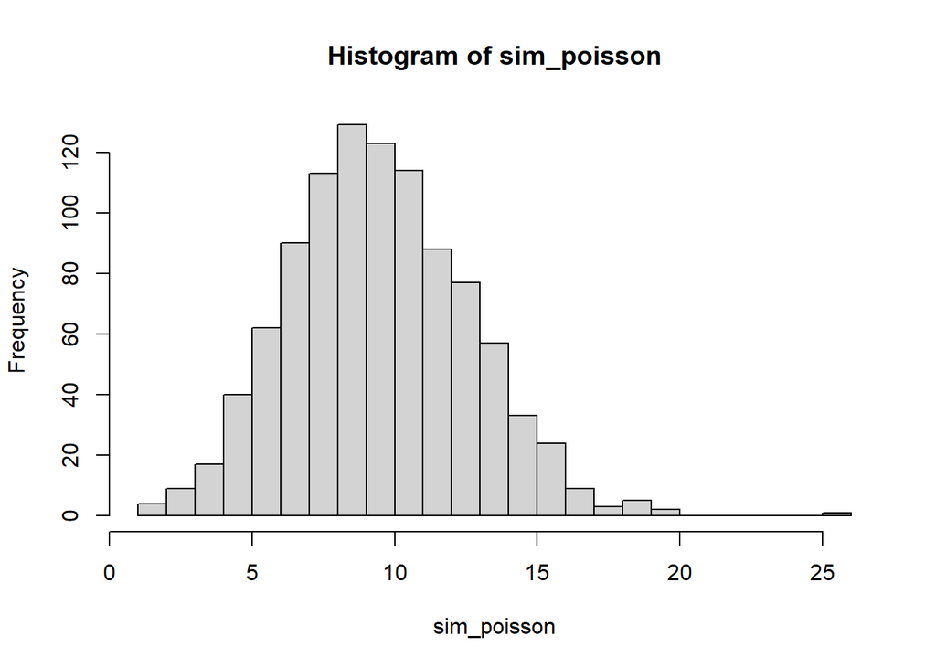

```r
sim_poisson <- rpois(n = 1000, lambda = 10)
hist(sim_poisson, breaks = round(max(sim_poisson)+1))
```

### Negative Binomial Distribution

The negative binomial distribution is a discrete probability distribution that models the number of failures in a sequence of independent and identically distributed Bernoulli trials before a specified/constant/fixed number of successes $r$ occur. For example, we can define rolling a 6 on some dice as a success, and rolling any other number as a failure, and ask how many failure rolls will occur before we see the third success ($r = 3$). In such a case, the probability distribution of the number of failures that appear will be a negative binomial distribution.

The negative binomial distribution has two parameters $r$ or `size`, which is the  
target for the number of successful trials, and $p$ or `p` which is the probability of success.

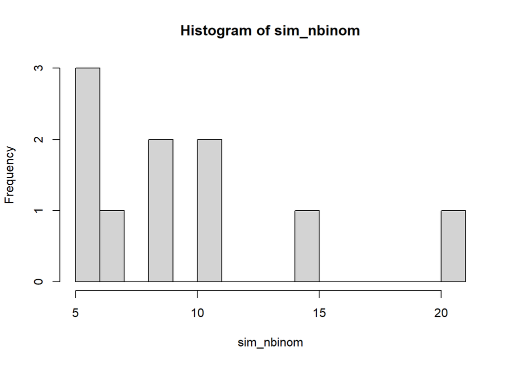

```r
sim_nbinom <- rnbinom(n = 10, size = 10, prob = 0.5)
hist(sim_nbinom, breaks = round(max(sim_nbinom)+1))
```

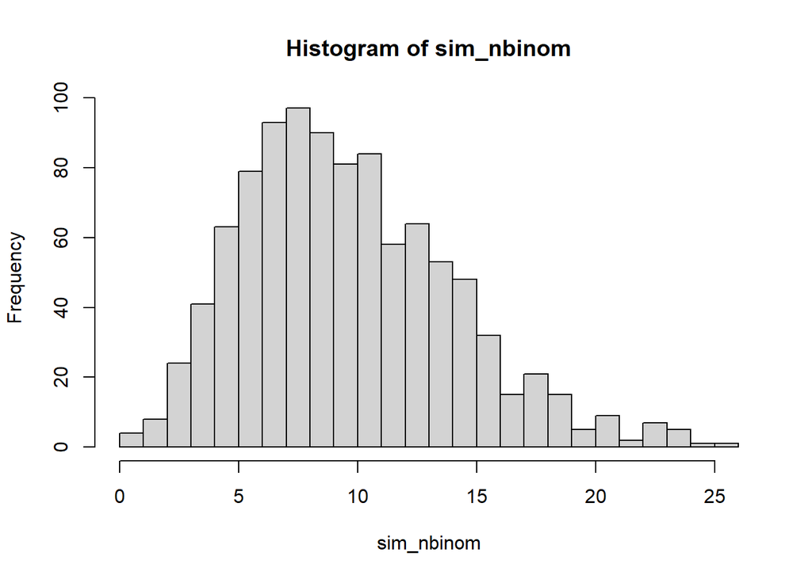

```r
sim_nbinom <- rnbinom(n = 1000, size = 10, prob = 0.5)
hist(sim_nbinom, breaks = round(max(sim_nbinom)+1))
```

## Continuous Distributions

### Normal Distribution

A normal distribution or Gaussian distribution is a type of continuous probability distribution for a real-valued random variable. The parameter $\mu$ is the mean or expectation of the distribution (and also its median and mode), while the parameter $\sigma^2$ is the variance. Normal distributions are important in statistics and are often used in the natural and social sciences to represent real-valued random variables whose distributions are not known. Their importance is partly due to the central limit theorem. It states that, under some conditions, the average of many samples (observations) of a random variable with finite mean and variance is itself a random variable–whose distribution converges to a normal distribution as the number of samples increases. Therefore, physical quantities that are expected to be the sum of many independent processes, such as measurement errors, often have distributions that are nearly normal.

[Video on the central limit theorem](https://www.youtube.com/watch?v=jvoxEYmQHNM)

The two parameters of the normal distribution are the mean ($\mu$) and variance ($\sigma^2$), but you need to specify the `mean` and standard deviation `sd` ($\sigma$). We can approximate the probability density function (PDF) using a histogram, but it’s not perfect and the smoothness depends on the number of breaks.

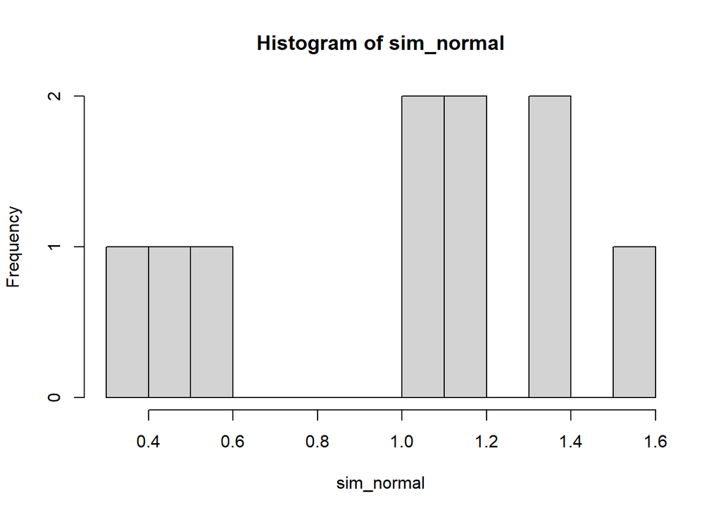

```r
sim_normal <- rnorm(n = 10, mean = 1, sd = 0.5)
hist(sim_normal, breaks = round(max(sim_normal)*10))
```

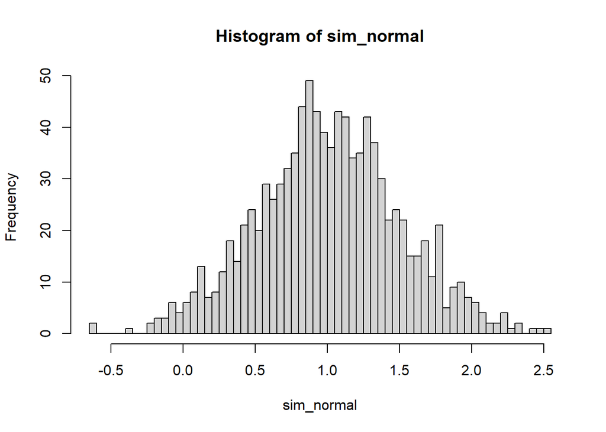

```r
sim_normal <- rnorm(n = 1000, mean = 1, sd = 0.5)
hist(sim_normal, breaks = round(max(sim_normal)*20))
```

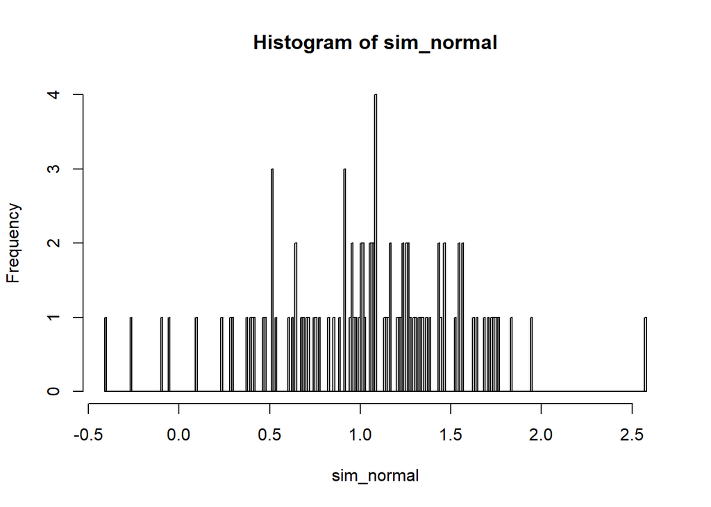

```r
sim_normal <- rnorm(n = 100, mean = 1, sd = 0.5)
hist(sim_normal, breaks = round(max(sim_normal)*100))
```

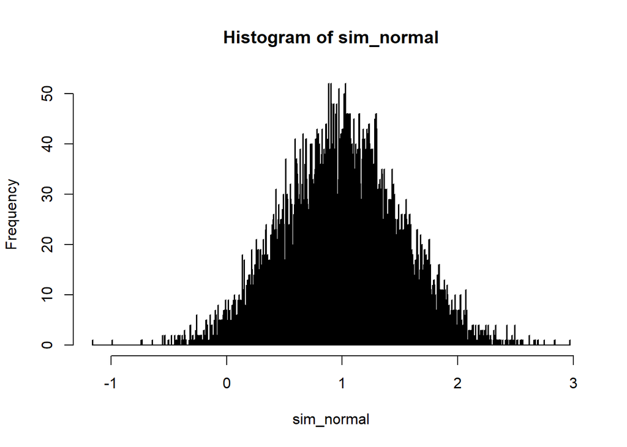

```r
sim_normal <- rnorm(n = 10000, mean = 1, sd = 0.5)
hist(sim_normal, breaks = round(max(sim_normal)*200))
```

### Gamma Distribution

The gamma distribution is a versatile two-parameter family of continuous probability distributions. There are two equivalent parameterizations in common use:

1. With a shape parameter $\alpha$ and a scale parameter $\theta$
2. With a shape parameter $\alpha$ and a rate parameter $\lambda =1/\theta$

In each of these forms, both parameters are positive real numbers. The gamma distribution is integral to modeling a range of phenomena due to its flexible shape, which can capture various statistical distributions, including the exponential and chi-squared distributions under specific conditions.

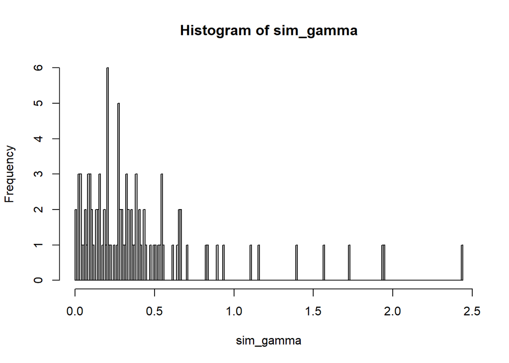

```r
sim_gamma <- rgamma(n = 100, shape = 1, rate = 2)
hist(sim_gamma, breaks = round(max(sim_gamma)*100))
```

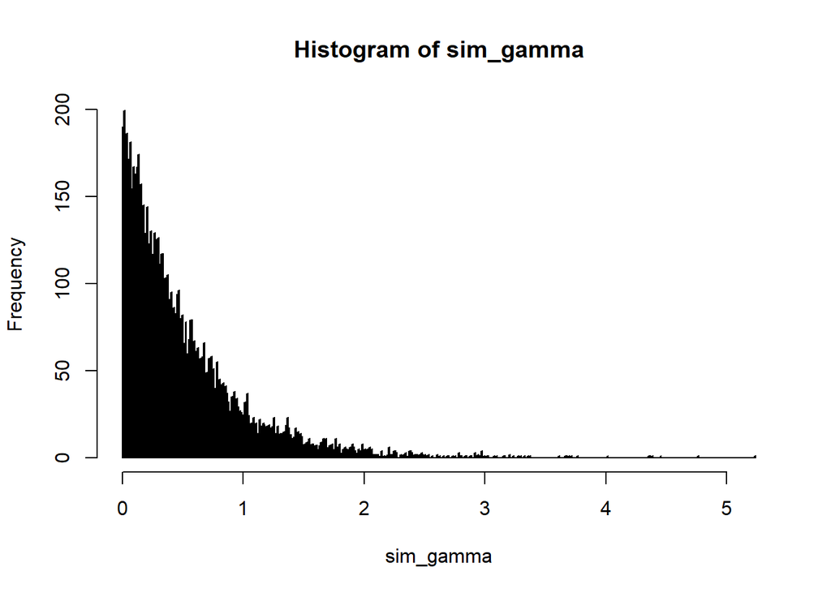

```r
sim_gamma <- rgamma(n = 10000, shape = 1, rate = 2)
hist(sim_gamma, breaks = round(max(sim_gamma)*100))
```

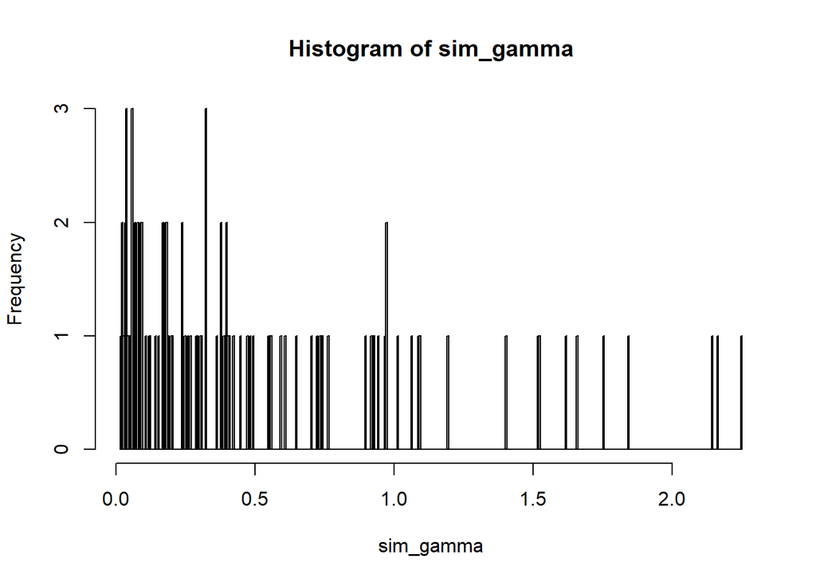

```r
sim_gamma <- rgamma(n = 100, shape = 1, scale = 0.5)
hist(sim_gamma, breaks = round(max(sim_gamma)*200))
```

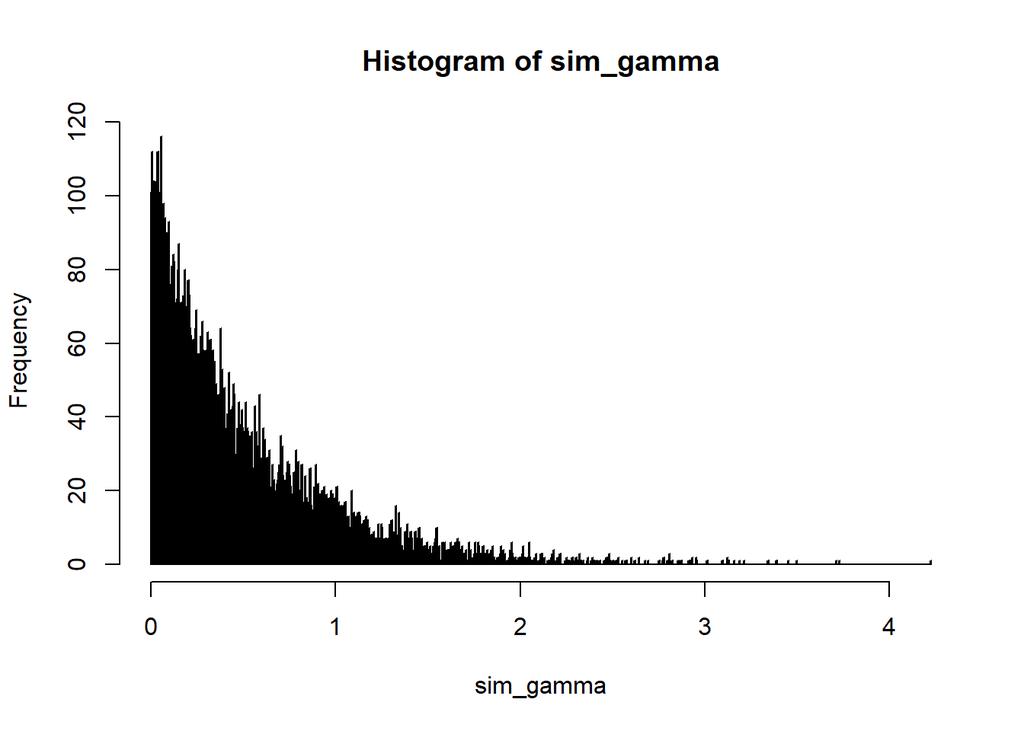

```r
sim_gamma <- rgamma(n = 10000, shape = 1, scale = 0.5)
hist(sim_gamma, breaks = round(max(sim_gamma)*200))
```